# Paso 4.- Análisis GSEA (31773)

Borja Gómez

20/11/2021

#### Carga de paquetes y datos

A continuación se va a realizar un análisis de enriquecimiento funcional (GSEA) mediante el paquete mdgsa, lo que nos va a permitir analizar nuestros resultados no desde una visión gen a gen sino en una visión más global viendo que cluster de genes se encuentran estadísticamente sobre o infra representados en función a los resultados obtenidos anteriormente mediante limma, donde hemos extraído para cada uno de los grupos (control, asmáticos y severos) cuales eran sus genes significativos.

```r
library(mdgsa)
library(hgu133plus2.db)
load("data/dif_exprs_31773.rda")
```

Para el análisis de enriquecimiento funcional va a ser necesario cargar la información externa, en este caso vamos a emplear los términos de GO Ontology y las rutas KEGG.

```r
anmat <- toTable(hgu133plus2GO)
anmat_kegg <- toTable(hgu133plus2PATH)
```

Vamos a realizar un análisis individual para cada grupo experimental.

### 1.- Análisis para Asmáticos vs Control

#### 1.1.- Preparación de los datos

Primero necesitaremos obtener los p-valores y el estadístico t de los genes significativos. Estos valores los normalizaremos con indexTrasnform para poder realizar un modelo de regresión logística.

```r
rindex <- pval2index (pval = fit2$p.value[,1], sign = fit2$t[,1])
rindex <- indexTransform (rindex)
```

Podemos visualizar la variable rindex en función del estadístico T y el pvalue, para poder observar cual es la proporcion de genes sobre e infra expresados así como el valor de los p-valores obtenidos

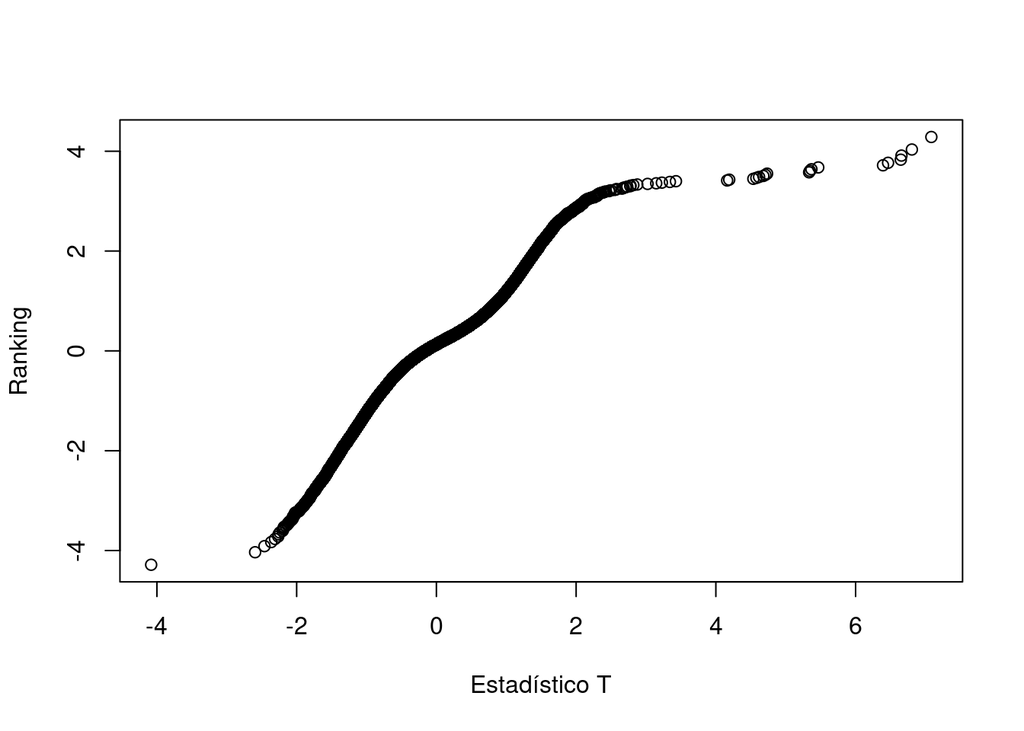

```r
plot (fit2$t[,1], rindex, xlab = "Estadístico T", ylab = "Ranking")
```

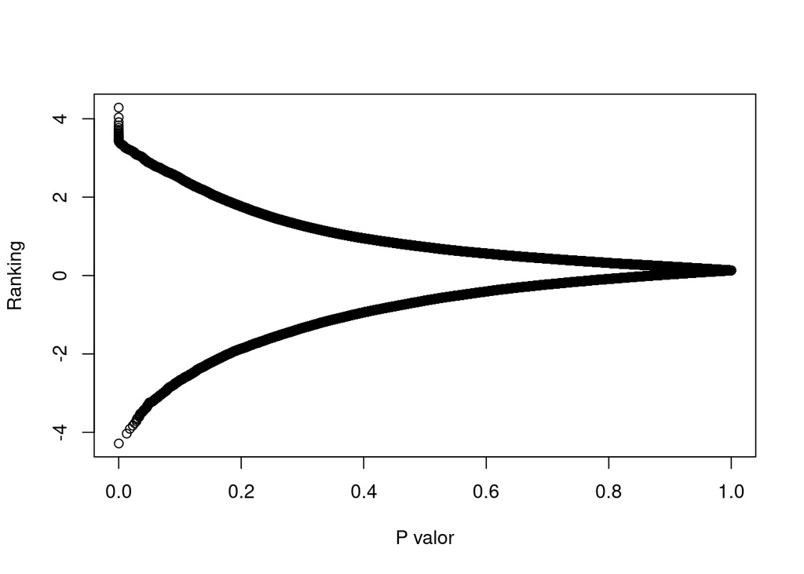

```r
plot (fit2$p.value[,1], rindex, xlab = "P valor", ylab = "Ranking")
```

#### 1.2.- Clusterización de genes

A continuación vamos a darle forma a la anotación, agrupando los distintos genes en clusters representados por términos GO usando la función annotMat2lis. Además debemos comprobar que nuestros genes significativos y los genes que acabamos de agrupar en clusters conformando nuestro “universo” de genes coinciden. También vamos a aprovechar para filtrar dichos clusters de forma que solo trabajaremos con aquellos con un tamaño 10:500 genes.

```r
annot<-annotMat2list(anmat)
annot<- annotFilter(annot, rindex, minBlockSize = 10, maxBlockSize = 500)

annot_kegg<-annotMat2list(anmat_kegg)
annot_kegg<- annotFilter(annot_kegg, rindex, minBlockSize = 10, maxBlockSize = 500)
```

#### 1.3.- Análisis GSEA

```r
res_asma = uvGsa(rindex, annot)
res_asma_kegg = uvGsa(rindex, annot_kegg)
```

#### 1.4.- Visionado de los resultados

Y una vez terminado podemos realizar el visionado de los resultados. Podemos emplear la función uvPat que va a clasificar los genes en significativos y upregulated, significativos y downregulated o no significativos. Además vamos a obtener el nombre de los terminos GO relacinoados con nuestros genes y finalmente nos quedaremos con aquellos cluster significativamente enriquecidos.

Primero lo hacemos para los términos GO

```r
res_asma[,"up/down"] <- uvPat(res_asma, cutoff = 0.05)
table(res_asma$`up/down`)

res_asma[,"GO"]<-getGOnames(res_asma)

resultado_asma <- uvSignif(res_asma)
resultado_asma = resultado_asma[order(resultado_asma$lor),]
save(resultado_asma, file ="data/diff_exprs_31773/asma_GO_31773.rda")
```

Vamos a hacer lo mismo para KEGG

```r
res_asma_kegg[,"up/down"] <- uvPat(res_asma_kegg, cutoff = 0.05)
table(res_asma_kegg$`up/down`)

res_asma_kegg[,"KEGG"]<-getKEGGnames(res_asma_kegg)

resultado_asma_kegg <- uvSignif(res_asma_kegg)
resultado_asma_kegg = resultado_asma_kegg[order(resultado_asma_kegg$lor),]
save(resultado_asma_kegg, file ="data/diff_exprs_31773/asma_KEGG_31773.rda")
```

### 2.- Análisis para Severos vs. Control y Asmáticos vs. Severos

Vamos a realizar le mismo proceso para severos y para enfermos (asmáticos vs. severo)

#### 2.1.- Severos

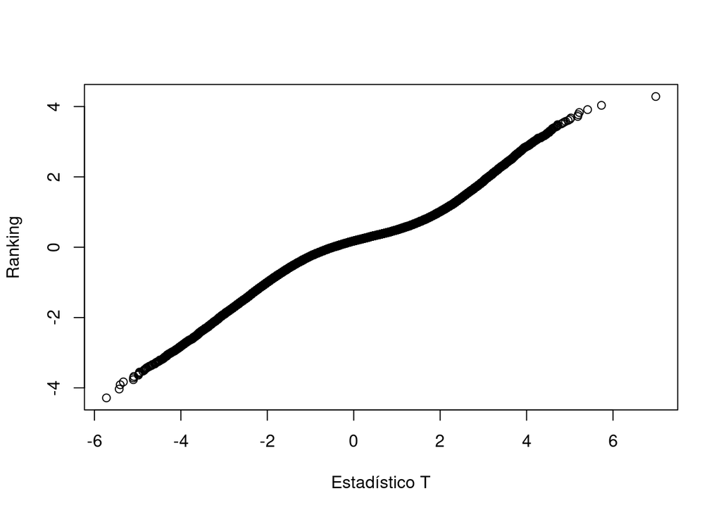

```r
anmat <- toTable(hgu133plus2GO)
anmat_kegg <- toTable(hgu133plus2PATH)

rindex <- pval2index (pval = fit2$p.value[,2], sign = fit2$t[,2])
rindex <- indexTransform (rindex)

plot (fit2$t[,2], rindex, xlab = "Estadístico T", ylab = "Ranking")
```

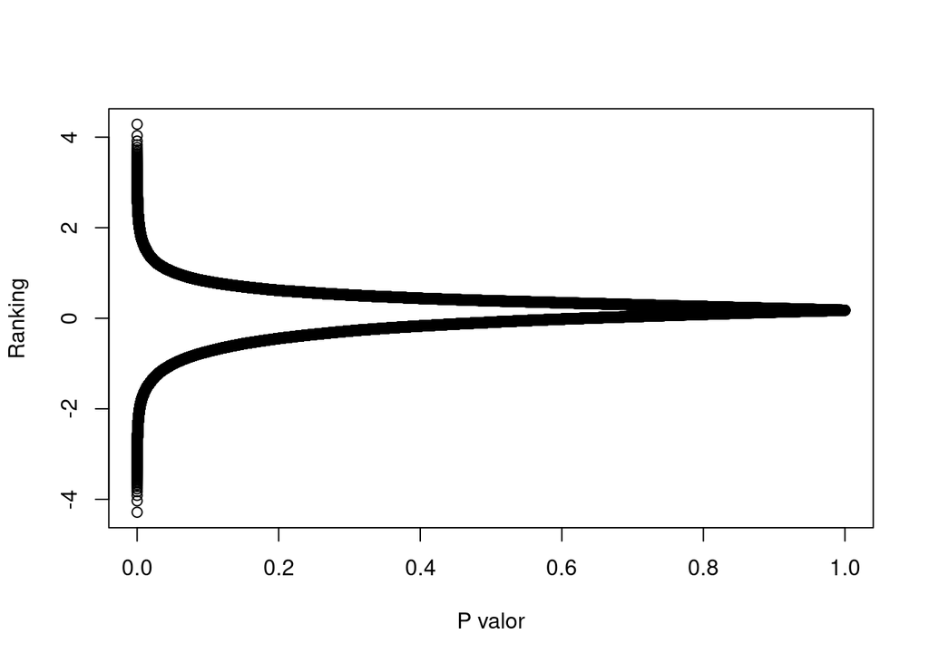

```r
plot (fit2$p.value[,2], rindex, xlab = "P valor", ylab = "Ranking")
```

```r
annot<-annotMat2list(anmat)
annot<- annotFilter(annot, rindex, minBlockSize = 10, maxBlockSize = 500)

annot_kegg<-annotMat2list(anmat_kegg)
annot_kegg<- annotFilter(annot_kegg, rindex, minBlockSize = 10, maxBlockSize = 500)
```

```r
res_severo = uvGsa(rindex, annot)
res_severo_kegg = uvGsa(rindex, annot_kegg)
```

```r
res_severo[,"up/down"] <- uvPat(res_severo, cutoff = 0.05)
table(res_severo$`up/down`)

res_severo[,"GO"]<-getGOnames(res_severo)

resultado_severo <- uvSignif(res_severo)
resultado_severo = resultado_severo[order(resultado_severo$lor),]
save(resultado_severo, file ="data/diff_exprs_31773/severo_GO_31773.rda")
```

```r
res_severo_kegg[,"up/down"] <- uvPat(res_severo_kegg, cutoff = 0.05)
table(res_severo_kegg$`up/down`)

res_severo_kegg[,"KEGG"]<-getKEGGnames(res_severo_kegg)

resultado_severo_kegg <- uvSignif(res_severo_kegg)
resultado_severo_kegg = resultado_severo_kegg[order(resultado_severo_kegg$lor),]
save(resultado_severo_kegg, file ="data/diff_exprs_31773/severo_KEGG_31773.rda")
```

#### 2.2.- Enfermos

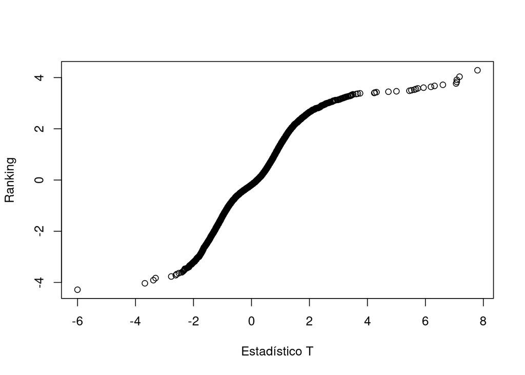

```r
anmat <- toTable(hgu133plus2GO)
anmat_kegg <- toTable(hgu133plus2PATH)

rindex <- pval2index (pval = fit2$p.value[,3], sign = fit2$t[,3])
rindex <- indexTransform (rindex)

plot (fit2$t[,3], rindex, xlab = "Estadístico T", ylab = "Ranking")
```

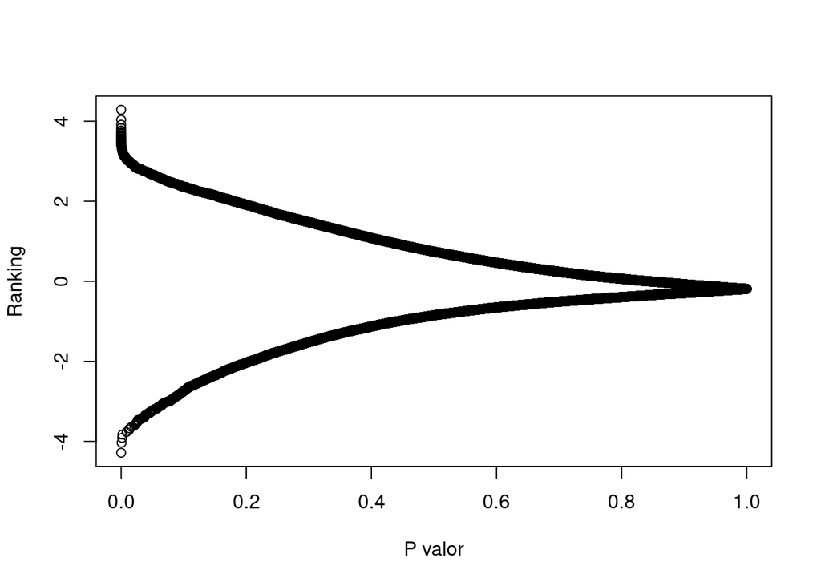

```r
plot (fit2$p.value[,3], rindex, xlab = "P valor", ylab = "Ranking")
```

```r
annot<-annotMat2list(anmat)
annot<- annotFilter(annot, rindex, minBlockSize = 10, maxBlockSize = 500)

annot_kegg<-annotMat2list(anmat_kegg)
annot_kegg<- annotFilter(annot_kegg, rindex, minBlockSize = 10, maxBlockSize = 500)
```

```r
res_enfermos = uvGsa(rindex, annot)
res_enfermos_kegg = uvGsa(rindex, annot_kegg)
```

```r
res_enfermos[,"up/down"] <- uvPat(res_enfermos, cutoff = 0.05)
table(res_enfermos$`up/down`)

res_enfermos[,"GO"]<-getGOnames(res_enfermos)

resultado_enfermos <- uvSignif(res_enfermos)
resultado_enfermos = resultado_enfermos[order(resultado_enfermos$lor),]
save(resultado_enfermos, file ="data/diff_exprs_31773/enfermos_GO_31773.rda")
```

```r
res_enfermos_kegg[,"up/down"] <- uvPat(res_enfermos_kegg, cutoff = 0.05)
table(res_enfermos_kegg$`up/down`)

res_enfermos_kegg[,"KEGG"]<-getKEGGnames(res_enfermos_kegg)

resultado_enfermos_kegg <- uvSignif(res_enfermos_kegg)
resultado_enfermos_kegg = resultado_enfermos_kegg[order(resultado_enfermos_kegg$lor),]
save(resultado_enfermos_kegg, file ="data/diff_exprs_31773/enfermos_KEGG_31773.rda")
```

### 3.- Filtrado de rutas

Finalmente nos vamos a quedar con las rutas KEGG significativas solo en uno de los grupos, descartando aquellas rutas significativas que aparecen en mas de grupo.

```r
rutas_asma = rownames(resultado_asma_kegg)
rutas_severo = rownames(resultado_severo_kegg)

exclusivas_severo<- setdiff(rutas_severo,rutas_asma)
exclusivas_asma<- setdiff(rutas_asma,rutas_severo)
rutas_asma_severo <- intersect(rutas_asma, rutas_severo)

exclusivas_severo = resultado_severo_kegg[exclusivas_severo,]
exclusivas_asma = resultado_asma_kegg[exclusivas_asma,]
comunes_asma_severo = resultado_severo_kegg[rutas_asma_severo,]
save(exclusivas_severo, file = "data/rutas_exclusivas/exclusivas_severo.rda" )
save(exclusivas_asma, file = "data/rutas_exclusivas/exclusivas_asma.rda" )
save(comunes_asma_severo, file = "data/rutas_exclusivas/comunes_asma_severo.rda" )
```